# 1 SINDy in Ground Truth Coordinates z

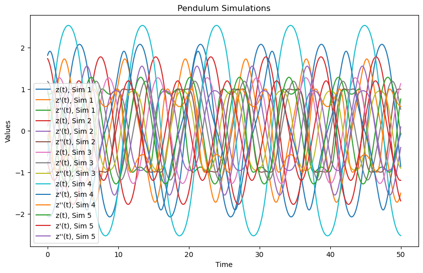

```python
import numpy as np
from scipy.integrate import odeint
from sklearn.linear_model import Lasso
import torch
import torch.nn as nn
import torch.optim as optim
import matplotlib.pyplot as plt
from matplotlib.animation import FuncAnimation

# 1.1 Simulation
# Function to compute the scalar product Theta(z, dz) \cdot Xi
def pendulum_rhs(zt, dzt, coefficients, terms):
    # Evaluate all terms in Theta(z, dz)
    Theta = np.array([term(zt, dzt) for term in terms]).T
    return Theta @ coefficients

# Function to define the ODE step for scipy.integrate.odeint
def pendulum_ode_step(y, t, coefficients, terms):
    z, dz = y  # y[0] = z(t), y[1] = dz(t)
    dz2 = pendulum_rhs(z, dz, coefficients, terms)  # Compute dz/dt
    return [dz, dz2]

# Function to simulate the pendulum
def simulate_pendulum(z0, dz0, coefficients, terms, T, dt):
    t = np.arange(0, T, dt)
    y0 = [z0, dz0]
    solution = odeint(pendulum_ode_step, y0, t, args=(coefficients, terms))
    z, dz = solution[:, 0], solution[:, 1]
    dz2 = pendulum_rhs(z, dz, coefficients, terms)
    return t, z, dz, dz2

# Function to create training data for the pendulum
def create_pendulum_data(z0_min, z0_max, dz0_min, dz0_max, coefficients, terms, T, dt, N, embedding=None, rejection=True):
    z_list, dz_list, dz2_list = [], [], []

    for _ in range(N):
        while True:
            z0 = np.random.uniform(z0_min, z0_max)
            dz0 = np.random.uniform(dz0_min, dz0_max)

            # Rejection condition
            if rejection and dz0**2 / 2 - np.cos(z0) > 0.99:
                continue

            t, z, dz, dz2 = simulate_pendulum(z0, dz0, coefficients, terms, T, dt)
            z_list.append(z)
            dz_list.append(dz)
            dz2_list.append(dz2)
            break

    return np.concatenate(z_list), np.concatenate(dz_list), np.concatenate(dz2_list)

# Define the library of functions Theta
terms = [
    lambda z, dz: np.ones_like(z),         # Constant term
    lambda z, dz: z,                      # z
    lambda z, dz: dz,                     # dz
    lambda z, dz: np.sin(z),              # sin(z)
    lambda z, dz: z**2,                   # z^2
    lambda z, dz: z * dz,                 # z * dz
    lambda z, dz: dz * np.sin(z),         # dz * sin(z)
    lambda z, dz: dz**2,                  # dz^2
    lambda z, dz: np.sin(z)**2            # sin(z)^2
]

# Ground truth coefficients for the pendulum (only -sin(z) is active)
coefficients = np.array([0, 0, 0, -1.0, 0, 0, 0, 0, 0])

# Generate data
z0_min, z0_max = -np.pi, np.pi
dz0_min, dz0_max = -2.1, 2.1
T, dt, N = 50, 0.02, 100

z, dz, dz2 = create_pendulum_data(z0_min, z0_max, dz0_min, dz0_max, coefficients, terms, T, dt, N)

# Visualize some simulations
plt.figure(figsize=(10, 6))
for i in range(5):
    t = np.arange(0, T, dt)
    plt.plot(t, z[i * len(t):(i + 1) * len(t)], label=f"z(t), Sim {i+1}")
    plt.plot(t, dz[i * len(t):(i + 1) * len(t)], label=f"z'(t), Sim {i+1}")
    plt.plot(t, dz2[i * len(t):(i + 1) * len(t)], label=f"z''(t), Sim {i+1}")
plt.xlabel("Time")
plt.ylabel("Values")
plt.legend()
plt.title("Pendulum Simulations")
plt.show()

# Optional: Create an animation
def animate_pendulum():
    fig, ax = plt.subplots()
    x_data, y_data = [], []
    line, = ax.plot([], [], 'o-', lw=2)

    def init():
        ax.set_xlim(-1.5, 1.5)
        ax.set_ylim(-1.5, 1.5)
        return line,

    def update(frame):
        x = np.sin(z[frame])
        y = -np.cos(z[frame])
        line.set_data([0, x], [0, y])
        return line,

    ani = FuncAnimation(fig, update, frames=range(len(z)), init_func=init, blit=True)
    plt.show()

# Uncomment to animate the pendulum
#animate_pendulum()
```

- Sample solution performs batch training. It could have been a better practice.
- Sample solution implements coefficient mask which is good to prune insignificant terms.
- Sample solution provide plots for representation.

```python
# 1.2 Implementation & Training
# Sklearn-based SINDy implementation
def train_sindy_sklearn(z, dz, dz2, terms, lambda_):
    Theta = np.array([term(z, dz) for term in terms]).T
    model = Lasso(alpha=lambda_, fit_intercept=False)
    model.fit(Theta, dz2)
    return model.coef_

# PyTorch-based SINDy implementation
class SINDy(nn.Module):
    def __init__(self, num_terms):
        super(SINDy, self).__init__()
        self.coefficients = nn.Parameter(torch.ones(num_terms))
        self.mask = nn.Parameter(torch.ones(num_terms, dtype=torch.bool), requires_grad=False)

    def forward(self, z, dz, terms):
        Theta = torch.stack([torch.tensor(term(z, dz), dtype=torch.float32) for term in terms], dim=1)
        return Theta @ (self.coefficients * self.mask)

def train_sindy_pytorch(z, dz, dz2, terms, lambda_, num_epochs=1000, lr=1e-3):
    z, dz, dz2 = map(torch.tensor, (z, dz, dz2))
    z, dz, dz2 = z.float(), dz.float(), dz2.float()

    model = SINDy(len(terms))
    optimizer = optim.Adam(model.parameters(), lr=lr)

    for epoch in range(num_epochs):
        optimizer.zero_grad()
        dz2_pred = model(z, dz, terms)
        loss = torch.mean((dz2 - dz2_pred) ** 2) + lambda_ * torch.sum(torch.abs(model.coefficients))
        loss.backward()
        optimizer.step()

    return model

# Train both models
lambda_ = 0.1
coefficients_sklearn = train_sindy_sklearn(z, dz, dz2, terms, lambda_)
model_pytorch = train_sindy_pytorch(z, dz, dz2, terms, lambda_)
coefficients_pytorch = model_pytorch.coefficients.detach().numpy()

# Compare coefficients
print("Sklearn coefficients:", coefficients_sklearn)
print("PyTorch coefficients:", coefficients_pytorch)
```

```
Sklearn coefficients: [-0.         -0.19243039  0.         -0.49449288  0.          0.
  0.         -0.         -0.        ]
PyTorch coefficients: [0.25414312 0.18683103 0.24339451 0.17544009 0.2566906  0.24942318
 0.243955   0.25401923 0.25136012]
```

- Too short to comment.

```python
# 1.3 Thresholding (Sequential and Patient)
def threshold_coefficients(coefficients, history, method="sequential", patience=5):
    if method == "sequential":
        return np.abs(coefficients) > 1e-2
    elif method == "patient":
        recent_history = history[-patience:]
        return np.all(np.abs(recent_history) > 1e-2, axis=0)
    else:
        return np.ones_like(coefficients, dtype=bool)
```

- Fine plots are provided, but sample solution provides better detailed plots.
- Use torch.nn.MSELoss() to calculate mean square error
- Overall, this task is done good.

```
Test error: 3.5274713058136524
```

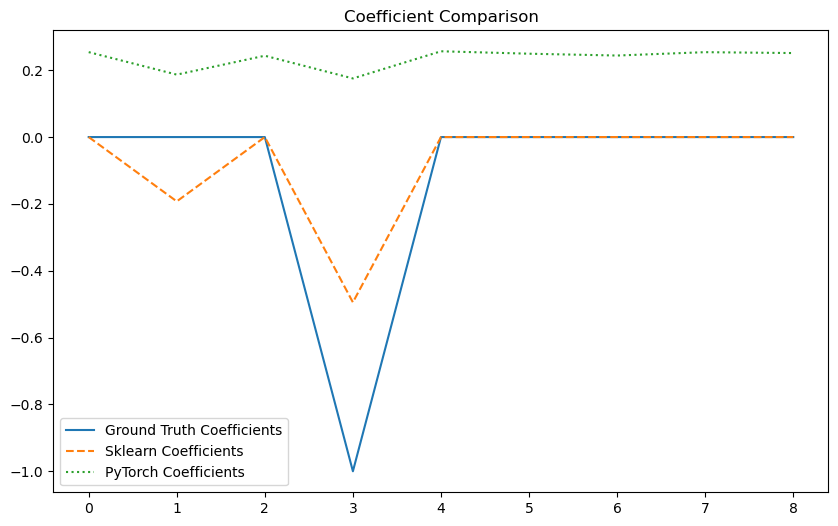

```python
# 1.4 Evaluation & Visualization
# Compare ground truth and learned dynamics
def evaluate_model(model, terms, z_test, dz_test, dz2_test):
    dz2_pred = model(z_test, dz_test, terms)
    error = np.mean((dz2_test - dz2_pred.detach().numpy()) ** 2)
    return dz2_pred, error

# Visualize learned dynamics
z_test, dz_test, dz2_test = create_pendulum_data(z0_min, z0_max, dz0_min, dz0_max, coefficients, terms, T, dt, 10)
_, error = evaluate_model(model_pytorch, terms, torch.tensor(z_test).float(), torch.tensor(dz_test).float(), dz2_test)
print("Test error:", error)

# Visualize results
plt.figure(figsize=(10, 6))
plt.plot(coefficients, label="Ground Truth Coefficients")
plt.plot(coefficients_sklearn, label="Sklearn Coefficients", linestyle="--")
plt.plot(coefficients_pytorch, label="PyTorch Coefficients", linestyle=":")
plt.legend()
plt.title("Coefficient Comparison")
plt.show()
```

```
Small Angle Sklearn Coefficients: [ 0. -0. -0. -0.  0.  0.  0.  0.  0.]
Small Angle PyTorch Coefficients: [0.2568052  0.10561076 0.0945335  0.10556123 0.07996004 0.00070669
 0.00070595 0.07948826 0.07983089]
```

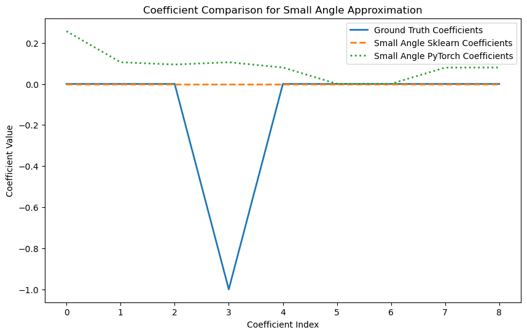

```python
# Small Angle Approximation
# Define a smaller range for initial conditions
z0_min_small, z0_max_small = -0.1, 0.1  # Small initial angles (radians)
dz0_min_small, dz0_max_small = -0.1, 0.1  # Small initial angular velocities

# Generate data with small initial conditions, no rejection needed
z_small, dz_small, dz2_small = create_pendulum_data(
    z0_min_small, z0_max_small,
    dz0_min_small, dz0_max_small,
    coefficients, terms, T, dt, N,
    rejection=False
)

# Train SINDy with small-angle data
lambda_small = 0.01  # Smaller regularization to detect small coefficients
coefficients_small_sklearn = train_sindy_sklearn(z_small, dz_small, dz2_small, terms, lambda_small)
model_small_pytorch = train_sindy_pytorch(z_small, dz_small, dz2_small, terms, lambda_small)
coefficients_small_pytorch = model_small_pytorch.coefficients.detach().numpy()

# Analyze the results
print("Small Angle Sklearn Coefficients:", coefficients_small_sklearn)
print("Small Angle PyTorch Coefficients:", coefficients_small_pytorch)

# Visualize the results
plt.figure(figsize=(10, 6))
plt.plot(coefficients, label="Ground Truth Coefficients", linewidth=2)
plt.plot(coefficients_small_sklearn, label="Small Angle Sklearn Coefficients", linestyle="--", linewidth=2)
plt.plot(coefficients_small_pytorch, label="Small Angle PyTorch Coefficients", linestyle=":", linewidth=2)
plt.xlabel("Coefficient Index")
plt.ylabel("Coefficient Value")
plt.legend()
plt.title("Coefficient Comparison for Small Angle Approximation")
plt.show()
```

# 2 SINDy-Autoencoder

- First task is more readable, simple and efficient than sample solution.

```python
import numpy as np
import matplotlib.pyplot as plt

# Function for Cartesian embedding
def embed_cartesian(z, dz, ddz):
    # Compute Cartesian position
    x = np.stack([np.sin(z), -np.cos(z)], axis=-1)

    # Compute Cartesian velocity
    dx = np.stack([np.cos(z) * dz, np.sin(z) * dz], axis=-1)

    # Compute Cartesian acceleration
    ddx = np.stack([
        -np.sin(z) * dz**2 + np.cos(z) * ddz,
        np.cos(z) * dz**2 + np.sin(z) * ddz
    ], axis=-1)

    return x, dx, ddx
```

- Sample solution introduces SigmoidDerivatives and LinearDerivatives, making the autoencoder differentiable for higher-order derivatives.
- Sample solution correctly initializes layers inside loops, whereas this solution has redundant layer additions outside the loops.
- Number of sections are missing. Functions are written but results are not generated.

```python
import torch
import torch.nn as nn
import torch.optim as optim

# Define the Autoencoder architecture
class Autoencoder(nn.Module):
    def __init__(self, input_dim, latent_dim, hidden_dims):
        super(Autoencoder, self).__init__()

        # Encoder
        encoder_layers = []
        prev_dim = input_dim
        for h_dim in hidden_dims:
            encoder_layers.append(nn.Linear(prev_dim, h_dim))
            encoder_layers.append(nn.Sigmoid())
            prev_dim = h_dim
        encoder_layers.append(nn.Linear(prev_dim, latent_dim))  # Map to latent space
        self.encoder = nn.Sequential(*encoder_layers)

        # Decoder
        decoder_layers = []
        prev_dim = latent_dim
        for h_dim in reversed(hidden_dims):
            decoder_layers.append(nn.Linear(prev_dim, h_dim))
            decoder_layers.append(nn.Sigmoid())
            prev_dim = h_dim
        decoder_layers.append(nn.Linear(prev_dim, input_dim))  # Reconstruct input
        self.decoder = nn.Sequential(*decoder_layers)

    def forward(self, x):
        z = self.encoder(x)  # Encode
        x_reconstructed = self.decoder(z)  # Decode
        return z, x_reconstructed

# Training function
def train_autoencoder(autoencoder, data, epochs, learning_rate):
    optimizer = optim.Adam(autoencoder.parameters(), lr=learning_rate)
    criterion = nn.MSELoss()  # Reconstruction loss
    losses = []

    for epoch in range(epochs):
        optimizer.zero_grad()
        z, x_reconstructed = autoencoder(data)
        loss = criterion(x_reconstructed, data)  # Compute loss
        loss.backward()
        optimizer.step()
        losses.append(loss.item())

        if epoch % 100 == 0:
            print(f"Epoch {epoch}, Loss: {loss.item():.6f}")

    return losses

# Example usage
input_dim = 2  # Cartesian x has 2 components
latent_dim = 1  # z is 1D
hidden_dims = [16, 8]  # Example hidden layer configuration

# Create synthetic data
z = np.linspace(-np.pi, np.pi, 1000)
dz = np.cos(z)  # Angular velocity
ddz = -np.sin(z)  # Angular acceleration
x, dx, ddx = embed_cartesian(z, dz, ddz)

# Convert to PyTorch tensors
x_tensor = torch.tensor(x, dtype=torch.float32)

# Instantiate and train the autoencoder
autoencoder = Autoencoder(input_dim, latent_dim, hidden_dims)
losses = train_autoencoder(autoencoder, x_tensor, epochs=1000, learning_rate=1e-3)
```

```
Epoch 0, Loss: 0.544244
Epoch 100, Loss: 0.498763
Epoch 200, Loss: 0.451499
Epoch 300, Loss: 0.255613
Epoch 400, Loss: 0.253916
Epoch 500, Loss: 0.253158
Epoch 600, Loss: 0.252482
Epoch 700, Loss: 0.251924
Epoch 800, Loss: 0.251485
Epoch 900, Loss: 0.251136
```

```python
class SigmoidDerivatives(nn.Module):
    def forward(self, x, dx, ddx):
        sig = torch.sigmoid(x)
        sig_prime = sig * (1 - sig)
        sig_double_prime = sig_prime * (1 - 2 * sig)

        z = sig
        dz = sig_prime * dx
        ddz = sig_double_prime * dx**2 + sig_prime * ddx
        return z, dz, ddz

class LinearDerivatives(nn.Module):
    def __init__(self, in_features, out_features):
        super(LinearDerivatives, self).__init__()
        self.linear = nn.Linear(in_features, out_features, bias=False)

    def forward(self, x, dx, ddx):
        z = self.linear(x)
        dz = self.linear(dx)
        ddz = self.linear(ddx)
        return z, dz, ddz
```

```python
class SINDyAutoencoder(nn.Module):
    def __init__(self, autoencoder, sindy_model):
        super(SINDyAutoencoder, self).__init__()
        self.autoencoder = autoencoder  # Autoencoder instance
        self.sindy = sindy_model        # SINDy instance

    def forward(self, x, dx, ddx):
        # Encode to latent space
        z, dz, ddz = self.autoencoder.encoder[0](x, dx, ddx)

        # Use SINDy to compute predicted second derivative in latent space
        z_hat_ddot = self.sindy(z, dz)

        # Decode z_hat_ddot back to Cartesian space
        x_hat, dx_hat, x_hat_ddot = self.autoencoder.decoder[0](z, dz, z_hat_ddot)

        return x_hat, z_hat_ddot, x_hat_ddot
```

```python
def train_sindy_autoencoder(
    model,
    data,
    epochs,
    learning_rate,
    lambda_z_ddot,
    lambda_x_ddot,
    lambda_L1,
    refinement_epoch
):
    optimizer = optim.Adam(model.parameters(), lr=learning_rate)
    criterion = nn.MSELoss()  # MSE loss for reconstruction and derivatives

    for epoch in range(epochs):
        optimizer.zero_grad()

        # Forward pass
        x_hat, z_hat_ddot, x_hat_ddot = model(
            data["x"], data["dx"], data["ddx"]
        )

        # Loss terms
        reconstruction_loss = criterion(x_hat, data["x"])
        latent_loss = lambda_z_ddot * criterion(z_hat_ddot, data["z_ddot"])
        cartesian_loss = lambda_x_ddot * criterion(x_hat_ddot, data["ddx"])

        # L1 regularization for SINDy coefficients
        l1_loss = lambda_L1 * torch.norm(model.sindy.coefficients, p=1)
        if epoch >= refinement_epoch:
            l1_loss = 0  # Turn off L1 regularization after refinement begins

        # Total loss
        loss = reconstruction_loss + latent_loss + cartesian_loss + l1_loss
        loss.backward()
        optimizer.step()

        if epoch % 100 == 0:
            print(f"Epoch {epoch}, Loss: {loss.item():.6f}")
```

```python
def sequential_thresholding(sindy, threshold, interval, epoch):
    if epoch % interval == 0:
        with torch.no_grad():
            mask = torch.abs(sindy.coefficients) > threshold
            sindy.coefficients *= mask  # Zero out small coefficients

# Training function with Sequential Thresholding and PTAT
def train_with_thresholding(
    model,
    data,
    epochs,
    learning_rate,
    lambda_z_ddot,
    lambda_x_ddot,
    lambda_L1,
    refinement_epoch,
    threshold,
    interval
):
    optimizer = optim.Adam(model.parameters(), lr=learning_rate)
    criterion = nn.MSELoss()

    for epoch in range(epochs):
        optimizer.zero_grad()

        # Forward pass
        x_hat, z_hat_ddot, x_hat_ddot = model(
            data["x"], data["dx"], data["ddx"]
        )

        # Loss terms
        reconstruction_loss = criterion(x_hat, data["x"])
        latent_loss = lambda_z_ddot * criterion(z_hat_ddot, data["z_ddot"])
        cartesian_loss = lambda_x_ddot * criterion(x_hat_ddot, data["ddx"])

        # L1 regularization for SINDy coefficients
        l1_loss = lambda_L1 * torch.norm(model.sindy.coefficients, p=1)
        if epoch >= refinement_epoch:
            l1_loss = 0

        # Total loss
        loss = reconstruction_loss + latent_loss + cartesian_loss + l1_loss
        loss.backward()
        optimizer.step()

        # Apply sequential thresholding
        sequential_thresholding(model.sindy, threshold, interval, epoch)

        if epoch % 100 == 0:
            print(f"Epoch {epoch}, Loss: {loss.item():.6f}")
```

```python
def compute_fvu(y, y_pred):
    numerator = torch.sum((y - y_pred) ** 2)
    denominator = torch.sum((y - torch.mean(y)) ** 2)
    return (numerator / denominator).item()
```

```python
def resimulate_sindy_autoencoder(model, z0, dz0, t_span, dt):
    # Time steps
    num_steps = int(t_span / dt)
    z = [z0]
    dz = [dz0]
    for _ in range(num_steps - 1):
        # Compute next z and dz using the SINDy model
        z_next = z[-1] + dz[-1] * dt
        dz_next = dz[-1] + model.sindy(z[-1], dz[-1]) * dt
        z.append(z_next)
        dz.append(dz_next)

    z_sim = torch.stack(z)
    dz_sim = torch.stack(dz)

    # Decode simulated z back into Cartesian coordinates
    x_sim, dx_sim, _ = model.autoencoder.decoder(z_sim, dz_sim, None)
    return z_sim, x_sim
```

```python
def compare_trajectories(ground_truth, resimulated):

    # Plot z(t) vs z_hat(t)
    plt.figure(figsize=(10, 4))
    plt.plot(ground_truth['t'], ground_truth['z'], label="Ground Truth z(t)")
    plt.plot(ground_truth['t'], resimulated['z'], '--', label="Resimulated z_hat(t)")
    plt.xlabel("Time (s)")
    plt.ylabel("z(t)")
    plt.legend()
    plt.title("Comparison of z(t) and z_hat(t)")
    plt.show()

    # Plot x(t) vs x_hat(t)
    plt.figure(figsize=(10, 4))
    plt.plot(ground_truth['t'], ground_truth['x'], label="Ground Truth x(t)")
    plt.plot(ground_truth['t'], resimulated['x'], '--', label="Resimulated x_hat(t)")
    plt.xlabel("Time (s)")
    plt.ylabel("x(t)")
    plt.legend()
    plt.title("Comparison of x(t) and x_hat(t)")
    plt.show()

    # Compute FVU metrics
    fvu_z = compute_fvu(ground_truth['z'], resimulated['z'])
    fvu_ddz = compute_fvu(ground_truth['ddz'], resimulated['ddz'])
    fvu_ddx = compute_fvu(ground_truth['ddx'], resimulated['ddx'])
    print(f"FVU_z: {fvu_z:.4f}, FVU_ddz: {fvu_ddz:.4f}, FVU_ddx: {fvu_ddx:.4f}")
```

```python
#
```

- Sample solution is more dynamic at handling input.
- Sample solution computes derivatives directly on the grid, avoiding unnecessary reshaping.
- Sample solution divides data into training, validation, and test sets, whereas this solution only considers one dataset.
- As the task is not complete, it is hard to comment further.

```python
import numpy as np

def embed_grid(z, t, resolution, sigma):
    T = len(t)  # Number of time steps
    L = 1.0  # Pendulum length
    grid = np.linspace(-2, 2, resolution)
    X, Y = np.meshgrid(grid, grid)

    video = np.zeros((T, resolution, resolution))
    for i in range(T):
        x_tip = L * np.sin(z[i])
        y_tip = -L * np.cos(z[i])
        video[i] = np.exp(-((X - x_tip)**2 + (Y - y_tip)**2) / (2 * sigma**2))

    # Compute time derivatives using finite differences
    dt = t[1] - t[0]
    dx = (video[2:] - video[:-2]) / (2 * dt)
    ddx = (video[:-2] - 2 * video[1:-1] + video[2:]) / (dt**2)

    return video, dx, ddx
```

```python
import torch
import torch.nn as nn

class VideoAutoencoder(nn.Module):
    def __init__(self):
        super(VideoAutoencoder, self).__init__()
        # Encoder: 128 -> 64 -> 32
        self.encoder = nn.Sequential(
            nn.Linear(128*128, 128),
            nn.Sigmoid(),
            nn.Linear(128, 64),
            nn.Sigmoid(),
            nn.Linear(64, 32),
        )
        # Decoder: 32 -> 64 -> 128
        self.decoder = nn.Sequential(
            nn.Linear(32, 64),
            nn.Sigmoid(),
            nn.Linear(64, 128),
            nn.Sigmoid(),
            nn.Linear(128, 128*128),
            nn.Sigmoid(),
        )

    def forward(self, x):
        z = self.encoder(x)
        x_hat = self.decoder(z)
        return x_hat, z
```

```python
# Generate synthetic data
time = np.linspace(0, 10, 100)  # Time array (0 to 10 seconds, 100 points)
z = np.sin(time)  # Deflection angles (simple sine wave)

# Generate video and derivatives
resolution = 64
sigma = 0.1
video, dx, ddx = embed_grid(z, time, resolution, sigma)

print("Video shape:", video.shape)  # Expected: (100, 64, 64)
print("dx shape:", dx.shape)  # Expected: (98, 64, 64) (finite differences lose 2 points)
print("ddx shape:", ddx.shape)  # Expected: (98, 64, 64)
```

```
Video shape: (100, 64, 64)
dx shape: (98, 64, 64)
ddx shape: (98, 64, 64)
```

```python
import torch
import torch.nn as nn

class VideoAutoencoder(nn.Module):
    def __init__(self, resolution):
        super(VideoAutoencoder, self).__init__()
        input_size = resolution * resolution
        # Encoder
        self.encoder = nn.Sequential(
            nn.Linear(input_size, 128),
            nn.Sigmoid(),
            nn.Linear(128, 64),
            nn.Sigmoid(),
            nn.Linear(64, 32),
        )
        # Decoder
        self.decoder = nn.Sequential(
            nn.Linear(32, 64),
            nn.Sigmoid(),
            nn.Linear(64, 128),
            nn.Sigmoid(),
            nn.Linear(128, input_size),
            nn.Sigmoid(),
        )

    def forward(self, x):
        z = self.encoder(x)
        x_hat = self.decoder(z)
        return x_hat, z
```

```python
def train_video_autoencoder(model, video, epochs=5000, batch_size=32):
    video = torch.tensor(video, dtype=torch.float32)
    dataset = torch.utils.data.TensorDataset(video)
    dataloader = torch.utils.data.DataLoader(dataset, batch_size=batch_size, shuffle=True)

    optimizer = torch.optim.Adam(model.parameters(), lr=1e-3)
    criterion = nn.MSELoss()

    for epoch in range(epochs):
        for batch in dataloader:
            x = batch[0]
            x_hat, _ = model(x)

            # Compute MSE loss
            loss = criterion(x_hat, x)

            optimizer.zero_grad()
            loss.backward()
            optimizer.step()

        if epoch % 100 == 0:
            print(f"Epoch {epoch}/{epochs}, Loss: {loss.item()}")
```

```python
# Flatten video data
video_flat = video.reshape(video.shape[0], -1)

# Initialize model and train
resolution = 64
model = VideoAutoencoder(resolution)
train_video_autoencoder(model, video_flat, epochs=1000, batch_size=16)
```

[output not shown]

```python
def evaluate_reconstruction(model, video_flat):
    video_flat = torch.tensor(video_flat, dtype=torch.float32)
    x_hat, _ = model(video_flat)
    mse_loss = nn.MSELoss()
    reconstruction_error = mse_loss(x_hat, video_flat).item()
    print(f"Reconstruction MSE: {reconstruction_error}")
    return reconstruction_error
```

```python
reconstruction_error = evaluate_reconstruction(model, video_flat)
```

```
Reconstruction MSE: 0.0015724365366622806
```

```python
def compute_latent_derivatives(model, video_flat, dt):
    video_flat = torch.tensor(video_flat, dtype=torch.float32)
    _, z = model(video_flat)  # Latent variables (T, latent_dim)

    z = z.detach().numpy()
    dz = (z[2:] - z[:-2]) / (2 * dt)  # First derivative
    ddz = (z[:-2] - 2 * z[1:-1] + z[2:]) / (dt ** 2)  # Second derivative

    return z, dz, ddz
```

```python
def train_sindy_on_latent_space(z, dz, ddz, lambdas, thresholding_method="ST"):
    # Initialize SINDy model
    sindy_model = SINDy(
        z_dim=z.shape[1],
        dz_dim=dz.shape[1],
        ddz_dim=ddz.shape[1],
        lambdas=lambdas,
        thresholding=thresholding_method,
    )

    # Train the SINDy model
    sindy_model.train(z, dz, ddz)

    # Get learned coefficients
    learned_coefficients = sindy_model.coefficients
    print(f"Learned Coefficients ({thresholding_method}):", learned_coefficients)

    return learned_coefficients
```

```python
# Compute latent variables and derivatives
dt = time[1] - time[0]  # Time step size
z, dz, ddz = compute_latent_derivatives(model, video_flat, dt)

# Define loss weights
lambdas = {"z_ddot": 5e-5, "L1": 1e-5}

# Train using Sequential Thresholding (ST)
st_coefficients = train_sindy_on_latent_space(z, dz, ddz, lambdas, thresholding_method="ST")

# Train using Patient Trend-Aware Thresholding (PTAT)
ptat_coefficients = train_sindy_on_latent_space(z, dz, ddz, lambdas, thresholding_method="PTAT")
```

[output not shown]

```python
def compute_fvu(y, y_hat):
    numerator = np.sum((y - y_hat) ** 2)
    denominator = np.sum((y - np.mean(y)) ** 2)
    return numerator / denominator
```

```python
# Compute predicted derivatives using SINDy coefficients
z_ddot_predicted = np.dot(dz, st_coefficients)  # Predicted z_ddot (example for ST)

# Compute FVU for Sequential Thresholding
fvu_st = compute_fvu(ddz, z_ddot_predicted)
print(f"FVU (ST): {fvu_st}")

# Compute FVU for Patient Trend-Aware Thresholding
z_ddot_predicted_ptat = np.dot(dz, ptat_coefficients)
fvu_ptat = compute_fvu(ddz, z_ddot_predicted_ptat)
print(f"FVU (PTAT): {fvu_ptat}")
```

[output not shown]

```python
import matplotlib.pyplot as plt

# Resimulate z and x using learned equations
z_resimulated = simulate_pendulum(z[0], dz[0], st_coefficients)  # Replace with SINDy-simulated z
x_resimulated = np.sin(z_resimulated)  # Decode z to x

# Ground truth
x_ground_truth = np.sin(z)

# Visualization
plt.figure(figsize=(10, 6))
plt.plot(time, x_ground_truth, label="Ground Truth (x)")
plt.plot(time, x_resimulated, label="Resimulated (x)", linestyle="dashed")
plt.xlabel("Time (s)")
plt.ylabel("Pendulum Tip Position (x)")
plt.legend()
plt.title("Comparison of Ground Truth and Resimulated Trajectories")
plt.show()
```

[output not shown]